# ML Lab Report – Predicting Post-Op Pain After Hip Replacement

Anwar Sameer

2025-04-18

## 3. Visual flow chart of pipeline

[interactive chart not shown]

## 4. Understanding the Data

```r
data <- read.csv("C:/Users/anwar/Downloads/Hip Replacement CCG 2021 (2).csv")
dim(data)
```

```
## [1] 5575   81
```

```r
str(data)
```

```
## 'data.frame':    5575 obs. of  81 variables:
##  $ Provider.Code                                 : chr  "00D" "00D" "00D" "00D" ...
##  $ Procedure                                     : chr  "Hip Replacement" "Hip Replacement" "Hip Replacement" "Hip Replacement" ...
##  $ Revision.Flag                                 : int  1 1 0 0 0 0 0 0 0 0 ...
##  $ Year                                          : chr  "2020/21" "2020/21" "2020/21" "2020/21" ...
##  $ Age.Band                                      : chr  "*" "*" "*" "*" ...
##  $ Gender                                        : chr  "*" "*" "*" "*" ...
##  $ Pre.Op.Q.Assisted                             : int  1 2 1 1 1 1 1 2 1 2 ...
##  $ Pre.Op.Q.Assisted.By                          : int  0 0 0 0 0 0 0 0 0 0 ...
##  $ Pre.Op.Q.Symptom.Period                       : int  1 1 2 2 2 3 4 2 2 2 ...
##  $ Pre.Op.Q.Previous.Surgery                     : int  2 1 2 2 2 2 2 2 2 2 ...
##  $ Pre.Op.Q.Living.Arrangements                  : int  2 1 1 1 2 1 1 1 1 1 ...
##  $ Pre.Op.Q.Disability                           : int  1 1 1 1 1 1 1 2 1 9 ...
##  $ Heart.Disease                                 : int  9 9 9 9 9 9 9 9 9 9 ...
##  $ High.Bp                                       : int  9 9 1 9 9 9 1 1 1 9 ...
```

[output cut: 67 more lines]

```r
summary(data$Hip.Replacement.Post.Op.Q.Pain)
```

```
##    Min. 1st Qu.  Median    Mean 3rd Qu.    Max.
##   0.000   2.000   3.000   3.028   4.000   9.000
```

### Target Variable Distribution

```r
table(data$Hip.Replacement.Post.Op.Q.Pain)
```

```
##
##    0    1    2    3    4    9
##  336  502  606 1410 2710   11
```

| Pain Score | Description | Count |
| --- | --- | --- |
| 0 | Severe | 336 |
| 1 | Moderate | 502 |
| 2 | Mild | 606 |
| 3 | Very mild | 1410 |
| 4 | No pain | 2710 |
| 9 | Missing/Invalid | 11 |

## 5. Data Preparation

```r
# Remove invalid pain scores
names(data) <- make.names(names(data))
clean_data <- data %>% filter(Hip.Replacement.Post.Op.Q.Pain <= 4)

# Drop irrelevant columns
drop_cols <- c("Provider.Code", "Procedure", "Year", "Hip.Replacement.Post.Op.Q.Score",
               "Hip.Replacement.OHS.Post.Op.Q.Predicted")

clean_data <- clean_data %>% select(-all_of(drop_cols))

# Convert factors
clean_data$Gender <- factor(clean_data$Gender, levels = c(1, 2), labels = c("Male", "Female"))
clean_data$Age.Band <- na_if(clean_data$Age.Band, "*")
clean_data$Age.Band <- factor(clean_data$Age.Band,
                               levels = c("Under 55", "55-59", "60-64", "65-69", "70-74", "75 and over"),
                               ordered = TRUE)

# Keep only numeric columns for correlation matrix
numeric_vars <- clean_data %>% select(where(is.numeric))
# Remove constant or NA-only columns
numeric_vars <- numeric_vars %>% select(where(~ var(.x, na.rm = TRUE) > 0))
```

## 6. Problem Type

This is a **supervised regression** problem because: - We are predicting a **numeric pain score** (0–4) - We have labeled outcomes for training

## 7. Feature Selection & Correlation

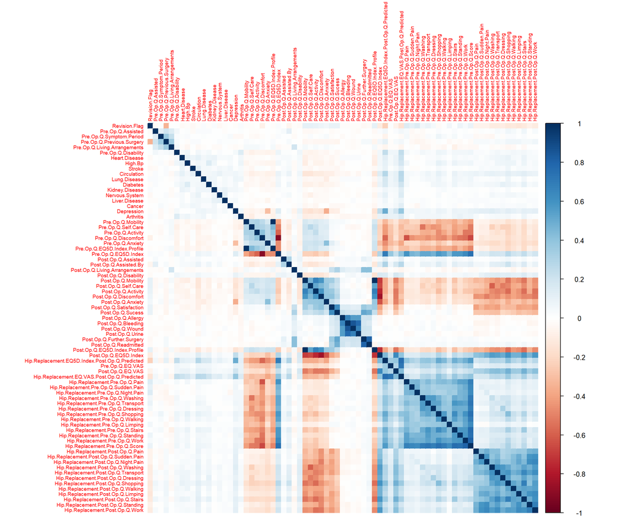

```r
# Correlation matrix for clean numeric variables
cor_matrix <- cor(numeric_vars, use = "complete.obs")
corrplot(cor_matrix, method = "color", tl.cex = 0.6)
```

## 8. Model Selection

We compare: - Linear Regression - Random Forest - XGBoost

## 9. Model Training & Evaluation

```r
set.seed(123)

# Standardize column names at the beginning
names(data) <- make.names(names(data))

# Refined filtering logic to preserve data while ensuring valid training
clean_data <- data %>%
  mutate(across(where(is.character), ~ trimws(.))) %>%
  filter(Hip.Replacement.Post.Op.Q.Pain %in% 0:4) %>%
  mutate(
    Gender = na_if(Gender, "*"),
    Age.Band = na_if(Age.Band, "*"),
    Gender = factor(Gender, levels = c(1, 2), labels = c("Male", "Female")),
    Age.Band = factor(Age.Band, levels = c("Under 55", "55-59", "60-64", "65-69", "70-74", "75 and over"), ordered = TRUE)
  ) %>%
  select(-Provider.Code, -Procedure, -Year, -Hip.Replacement.Post.Op.Q.Score, -Hip.Replacement.OHS.Post.Op.Q.Predicted)

# Print distribution for verification
print(table(clean_data$Hip.Replacement.Post.Op.Q.Pain))
```

```
##
##    0    1    2    3    4
##  336  502  606 1410 2710
```

```r
# Create new cleaned dataset for modeling only (drop rows with any NA)
model_data <- clean_data %>% select(where(~ !any(is.na(.)))) %>% drop_na()

# Split data
if (length(unique(model_data$Hip.Replacement.Post.Op.Q.Pain)) >= 2) {
  train_index <- createDataPartition(model_data$Hip.Replacement.Post.Op.Q.Pain, p = 0.8, list = FALSE)
  train_data <- model_data[train_index, ]
  test_data  <- model_data[-train_index, ]
} else {
  print("Warning: Only one class remains in the target variable after filtering. Using all data for training.")
  train_data <- model_data
  test_data  <- model_data
}

ctrl <- trainControl(method = "cv", number = 5)

model_lm <- train(Hip.Replacement.Post.Op.Q.Pain ~ ., data = train_data, na.action = na.omit, method = "lm", trControl = ctrl)
model_rf <- train(Hip.Replacement.Post.Op.Q.Pain ~ ., data = train_data, na.action = na.omit, method = "rf", trControl = ctrl, tuneLength = 3)
model_xgb <- train(Hip.Replacement.Post.Op.Q.Pain ~ ., data = train_data, na.action = na.omit, method = "xgbTree", trControl = ctrl, tuneLength = 3)
```

[output not shown]

[output cut: 305 more lines]

[output not shown]

```r
results <- resamples(list(Linear = model_lm, RF = model_rf, XGBoost = model_xgb))
summary(results)
```

```
##
## Call:
## summary.resamples(object = results)
##
## Models: Linear, RF, XGBoost
## Number of resamples: 5
##
## MAE
##              Min.   1st Qu.    Median      Mean   3rd Qu.      Max. NA's
## Linear  0.6740475 0.7124830 0.7205025 0.7177487 0.7352307 0.7464796    0
## RF      0.6837765 0.6980485 0.6994556 0.7010197 0.7037414 0.7200767    0
## XGBoost 0.6450008 0.6538076 0.6619587 0.6668994 0.6643583 0.7093718    0
##
## RMSE
##              Min.   1st Qu.    Median      Mean   3rd Qu.     Max. NA's
## Linear  0.9535569 0.9703575 0.9990077 0.9988744 1.0208478 1.050602    0
## RF      0.9402766 0.9596828 0.9748375 0.9787458 0.9852102 1.033722    0
## XGBoost 0.9128734 0.9339250 0.9389697 0.9550958 0.9495212 1.040190    0
##
## Rsquared
##              Min.   1st Qu.    Median      Mean   3rd Qu.      Max. NA's
## Linear  0.3023261 0.3036908 0.3313597 0.3317075 0.3487397 0.3724214    0
## RF      0.3245759 0.3318133 0.3652379 0.3593853 0.3801713 0.3951281    0
## XGBoost 0.3235626 0.3905108 0.3997209 0.3888528 0.4077268 0.4227429    0
```

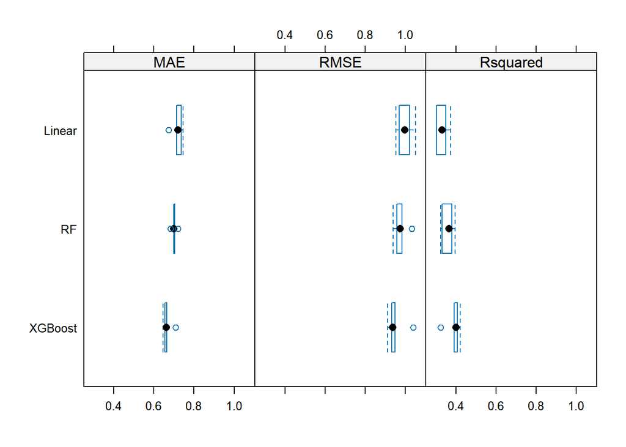

```r
bwplot(results)
```

## 10. Model Performance Summary

```r
# Evaluate actual performance on test data
lm_metrics <- postResample(predict(model_lm, test_data), test_data$Hip.Replacement.Post.Op.Q.Pain)
rf_metrics <- postResample(predict(model_rf, test_data), test_data$Hip.Replacement.Post.Op.Q.Pain)
xgb_metrics <- postResample(predict(model_xgb, test_data), test_data$Hip.Replacement.Post.Op.Q.Pain)

# Combine into summary table
eval_table <- data.frame(
  Model = c("Linear Regression", "Random Forest", "XGBoost"),
  MAE = c(lm_metrics["MAE"], rf_metrics["MAE"], xgb_metrics["MAE"]),
  RMSE = c(lm_metrics["RMSE"], rf_metrics["RMSE"], xgb_metrics["RMSE"]),
  R2 = c(lm_metrics["Rsquared"], rf_metrics["Rsquared"], xgb_metrics["Rsquared"])
)
eval_table
```

| Model | MAE | RMSE | R2 |
| --- | --- | --- | --- |
| Linear Regression | 0.7226575 | 1.028245 | 0.3168830 |
| Random Forest | 0.7062005 | 1.001968 | 0.3512179 |
| XGBoost | 0.6860151 | 0.991203 | 0.3653951 |

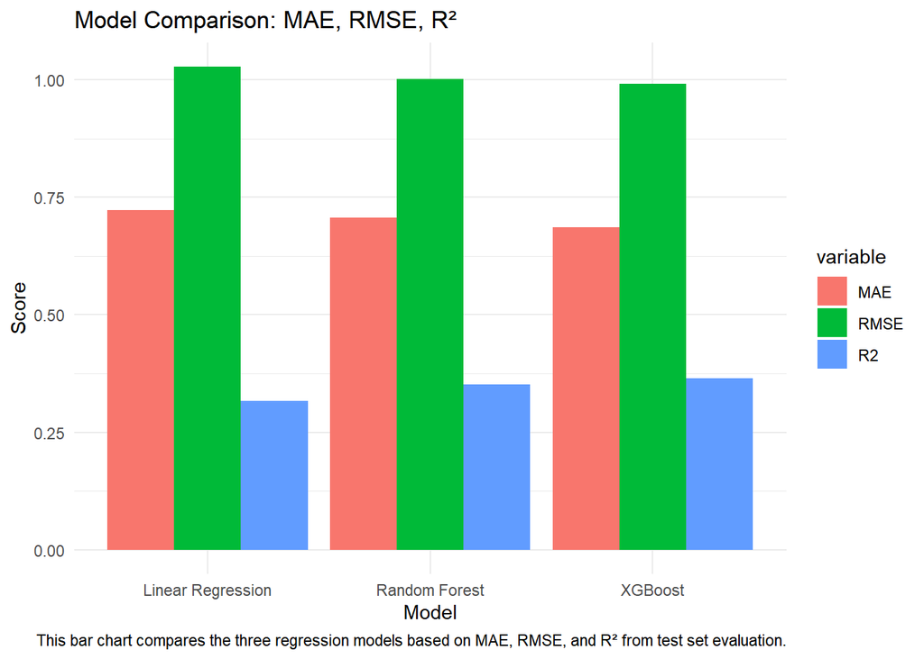

```r
# Bar plot of metrics
model_perf_melted <- melt(eval_table, id.vars = "Model")

ggplot(model_perf_melted, aes(x = Model, y = value, fill = variable)) +
  geom_bar(stat = "identity", position = "dodge") +
  labs(title = "Model Comparison: MAE, RMSE, R²",
       caption = "This bar chart compares the three regression models based on MAE, RMSE, and R² from test set evaluation.",
       y = "Score", x = "Model") +
  theme_minimal()
```

### Understanding the Metrics

The table above compares model performance across three key regression metrics:

- **RMSE (Root Mean Squared Error)**
  - Measures the square root of average squared errors.
  - Heavily penalizes larger prediction errors.
  - Lower RMSE means better fit.
- **MAE (Mean Absolute Error)**
  - Averages the absolute differences between predicted and actual values.
  - Easier to interpret because it’s in the same unit as the outcome.
  - Lower MAE indicates more accurate predictions.
- **R² (R-squared)**
  - Proportion of variance in the outcome explained by the model.
  - Ranges from 0 to 1.
    - **R² = 1**: perfect prediction
    - **R² = 0**: model performs no better than predicting the mean
  - Higher values indicate a better model

## 11. Feature Importance & Prediction

## Feature importance (Top 20)

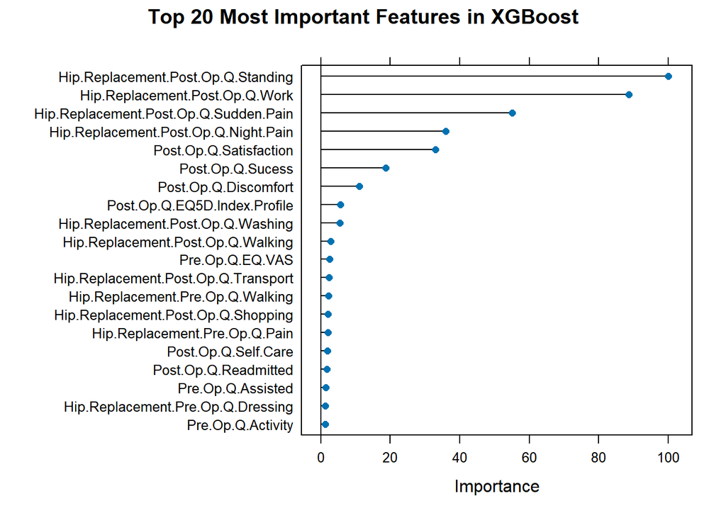

```r
vip <- varImp(model_xgb)
plot(vip, top = 20, main = "Top 20 Most Important Features in XGBoost")
```

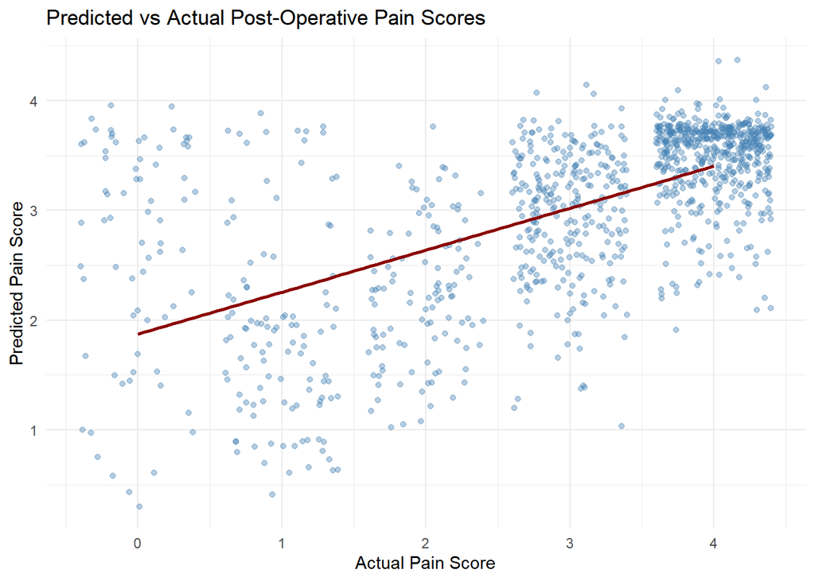

```r
# Predictions vs Actual Scores (Scatter Plot)
pred_xgb <- predict(model_xgb, test_data)
pred_df <- data.frame(
  Actual = test_data$Hip.Replacement.Post.Op.Q.Pain,
  Predicted = pred_xgb
)

ggplot(pred_df, aes(x = Actual, y = Predicted)) +
  geom_jitter(alpha = 0.4, color = "steelblue") +
  geom_smooth(method = "lm", se = FALSE, color = "darkred") +
  labs(
    title = "Predicted vs Actual Post-Operative Pain Scores",
    x = "Actual Pain Score",
    y = "Predicted Pain Score"
  ) +
  theme_minimal()
```

### SHAP-like Interpretation (Local)

```r
explainer_xgb <- explain(
  model = model_xgb,
  data = test_data %>% select(-Hip.Replacement.Post.Op.Q.Pain),
  y = test_data$Hip.Replacement.Post.Op.Q.Pain,
  label = "XGBoost Model"
)
```

```
## Preparation of a new explainer is initiated
##   -> model label       :  XGBoost Model
##   -> data              :  1112  rows  68  cols
##   -> target variable   :  1112  values
##   -> predict function  :  yhat.train  will be used (  default  )
##   -> predicted values  :  No value for predict function target column. (  default  )
##   -> model_info        :  package caret , ver. 7.0.1 , task regression (  default  )
##   -> predicted values  :  numerical, min =  0.3014629 , mean =  3.02059 , max =  4.370852
##   -> residual function :  difference between y and yhat (  default  )
##   -> residuals         :  numerical, min =  -3.955573 , mean =  -0.01609369 , max =  2.092972
##   A new explainer has been created!
```

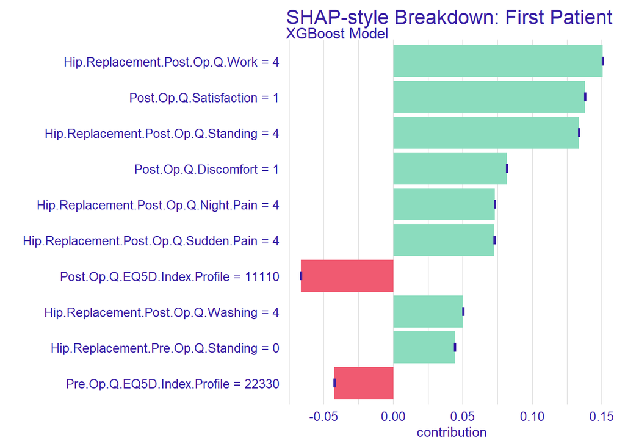

```r
shap_single <- predict_parts(
  explainer = explainer_xgb,
  new_observation = test_data[1, ],
  type = "shap"
)

plot(shap_single) + ggtitle("SHAP-style Breakdown: First Patient")
```

### SHAP-like Interpretation (Global)

[figure not shown]

```r
# Global variable importance (model_parts)
vi <- model_parts(explainer_xgb, type = "variable_importance")
plot(vi) + ggtitle("Global Variable Importance (Model-Based)")
```

## 12. Future Prediction

```r
# Re-define prediction function
predict_pain_score <- function(patient_data, model) {
  if ("Hip.Replacement.Post.Op.Q.Pain" %in% names(patient_data)) {
    patient_data <- patient_data %>% select(-Hip.Replacement.Post.Op.Q.Pain)
  }
  predict(model, newdata = patient_data)
}

# Select a real complete patient
complete_patients <- clean_data %>% filter(!is.na(Pre.Op.Q.EQ5D.Index), Gender != "*")
new_patient <- complete_patients[1, ]
predict_pain_score(new_patient, model_xgb)
```

```
## [1] 2.176884
```

## 13. Conclusion

#In-Depth Explanation of the Project

This project demonstrates the application of machine learning in predicting healthcare outcomes — specifically, post-operative pain levels in hip replacement patients — using structured survey data (PROMs) from the NHS.

### Data Preparation

- Cleaned invalid entries
- Converted categorical variables to factors
- Selected numeric columns for correlation analysis
- Removed NAs for model reliability

### Modeling

Three regression models were trained: - **Linear Regression**: as a baseline - **Random Forest**: for capturing non-linearities - **XGBoost**: high-performing gradient boosting model

The dataset was split into 80% training and 20% testing using stratified sampling. Models were evaluated using: - **MAE (Mean Absolute Error)** - **RMSE (Root Mean Squared Error)** - **R² (Variance Explained)**

### Future Use Case

A prediction function allows clinicians or systems to enter a new patient’s data and get a pain prediction.

## References

Baniecki, H., Biecek, P. and Paluszek, M., 2021. *ingredients: Descriptive Model Analysis*. [online] R package version 0.4.0. Available at: https://modeloriented.github.io/ingredients/ [Accessed 18 Apr. 2025].

Biecek, P., 2018. *DALEX: Explainers for Complex Predictive Models in R*. *Journal of Machine Learning Research*, 19(84), pp.1–5. Available at: https://jmlr.org/papers/v19/18-416.html [Accessed 18 Apr. 2025].

Chen, T. and Guestrin, C., 2016. *XGBoost: A Scalable Tree Boosting System*. In: *Proceedings of the 22nd ACM SIGKDD International Conference on Knowledge Discovery and Data Mining*. pp.785–794. DOI: https://doi.org/10.1145/2939672.2939785.

Kuhn, M., 2008. *Building Predictive Models in R Using the caret Package*. *Journal of Statistical Software*, 28(5), pp.1–26. Available at: https://www.jstatsoft.org/article/view/v028i05 [Accessed 18 Apr. 2025].

Lundberg, S.M. and Lee, S.-I., 2017. *A Unified Approach to Interpreting Model Predictions*. In: *Advances in Neural Information Processing Systems (NeurIPS)*, 30. Available at: https://proceedings.neurips.cc/paper_files/paper/2017/hash/8a20a8621978632d76c43dfd28b67767-Abstract.html [Accessed 18 Apr. 2025].

NHS Digital, 2021. *Patient Reported Outcome Measures (PROMs) in England: Hip Replacement CCG Level Data 2021* [dataset]. Version 3.4. Available at: https://digital.nhs.uk/data-and-information/publications/clinical-indicators/proms [Accessed 18 Apr. 2025].

Wickham, H., Averick, M., Bryan, J., Chang, W., McGowan, L.D., François, R., Grolemund, G., Hayes, A., Henry, L., Hester, J., Kuhn, M., Pedersen, T.L., Miller, E., Bache, S.M., Müller, K., Ooms, J., Robinson, D., Seidel, D.P., Spinu, V., Takahashi, K., Vaughan, D., Wilke, C., Woo, K. and Yutani, H., 2019. *Welcome to the Tidyverse*. *Journal of Open Source Software*, 4(43), p.1686. DOI: https://doi.org/10.21105/joss.01686.